# Rapport_glycemie_160_V2

CHAUVEAU Alice

2024-02-08

# Récupération des données et séparation

# Avant/Pendant/Après course

## Par date

#Mediane

#Trouver le participant median

#Creation Dataframe participant median ici le 9

#Quantile 0.25

#Quantile 0.75

#Mise en forme données

#Création dataframe final pour tracer le graphique avec les données médianes générales, données q1, données q3 et données du participant médian

#Graphique médiane et quantiles du glucose par jour avant, pendant et après la course 160km

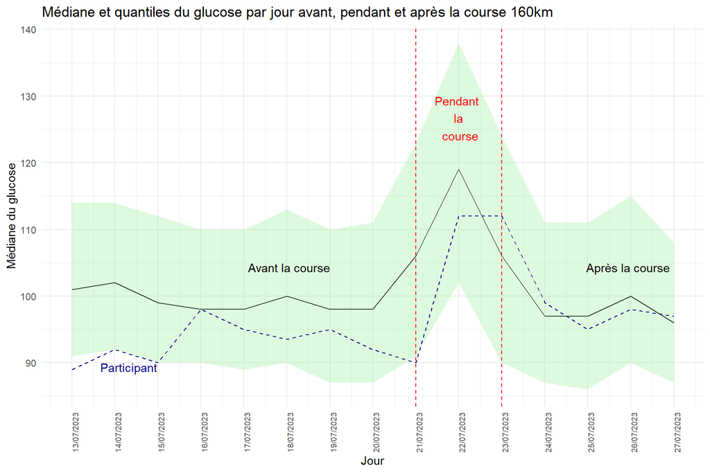

####################################################################################### ## Par heure #Mediane

#Trouver le participant median

#Quantile 0.25

#Quantile 0.75

#Creation dataframe participant median

#Mise en forme données

#Création dataframe final pour tracer le graphique avec les données médianes générales, données q1, données q3 et données du participant médian

#Graphique médiane et quantiles du glucose par heure avant, pendant et après la course 160km

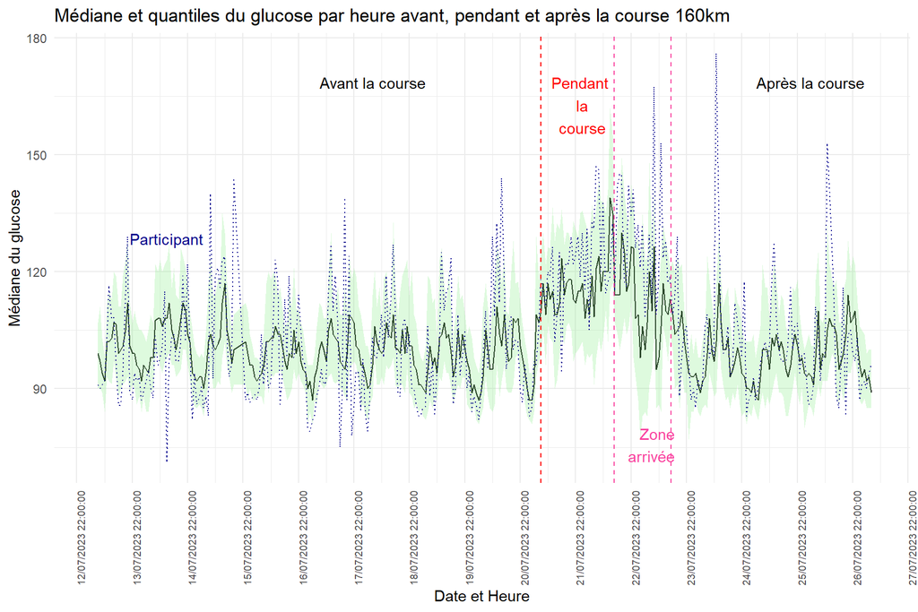

################################################################ # Pendant la course #Filtrer données de glycémie de la course entre début et fin de la course

##Par heure #Mediane

#Trouver le participant median

#Quantile 0.25

#Quantile 0.75

#Creation dataframe participant median

#Mise en forme données

#Création dataframe final pour tracer le graphique avec les données médianes générales, données q1, données q3 et données du participant médian

#Graphique médiane et quantiles du glucose par heure pendant la course 160 km

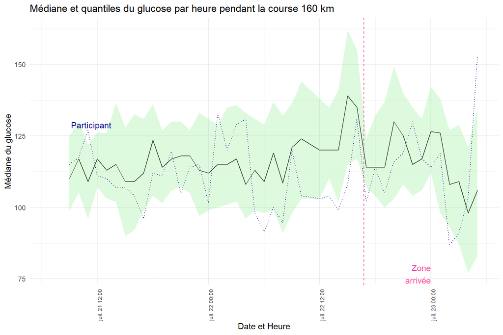

##Par minutes pendant la course #Création dataframe

#Graphique médiane et quantiles du glucose par minutes pendant la course 160 km

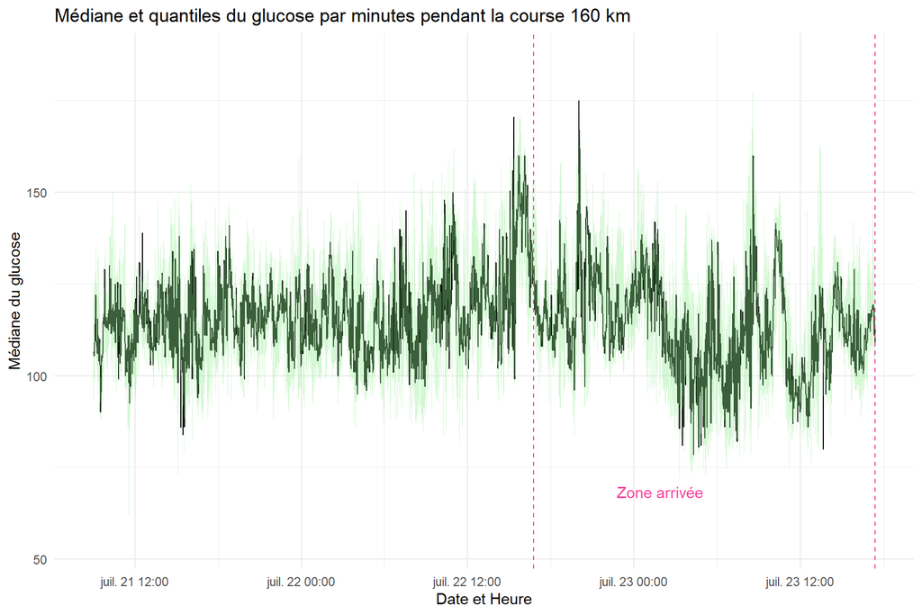

##Graphique de la glycémie des coureurs pednat la course #Abandons #Coureur 3

#Coureur 12

#Coureur 15

#Coureur 16

#Coureur 34

#Coureur 35

#Coureur 36

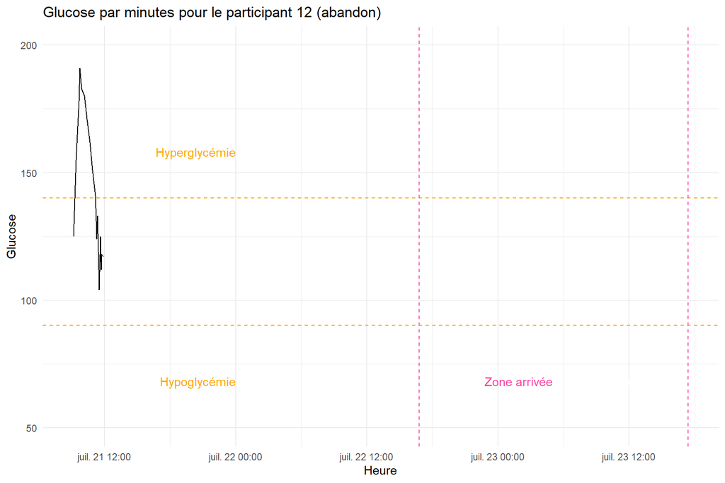

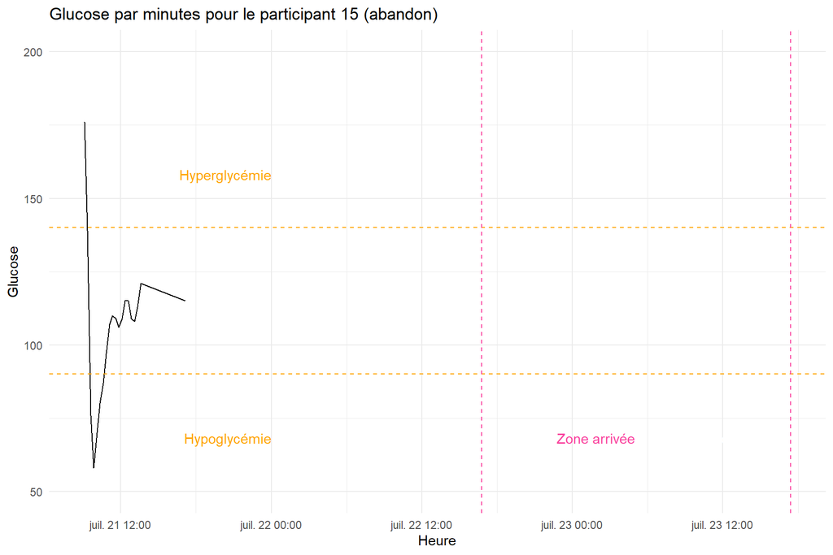

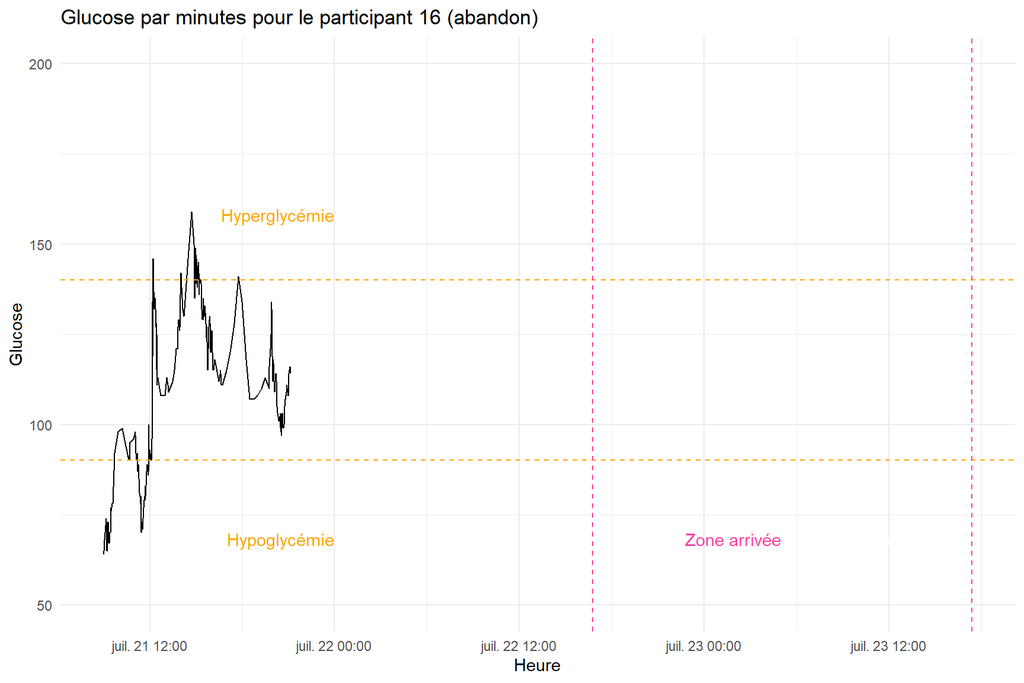

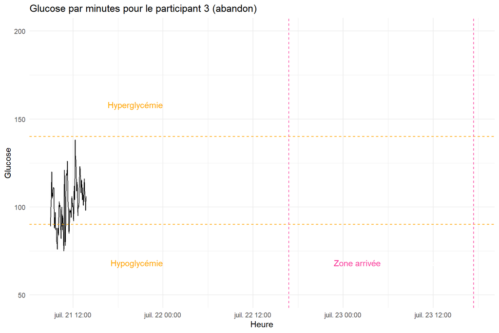

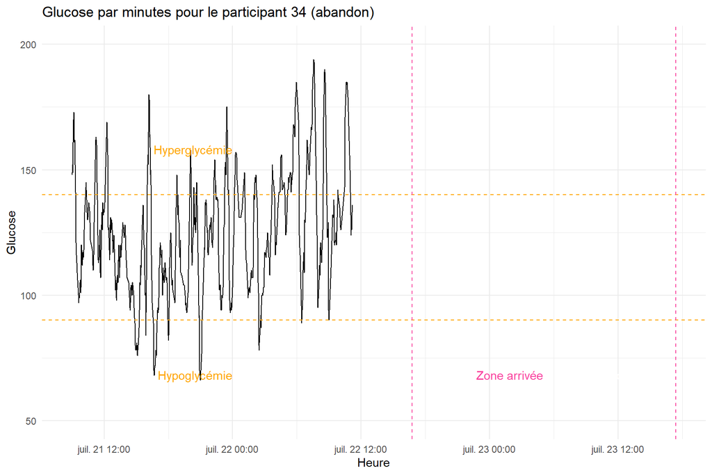

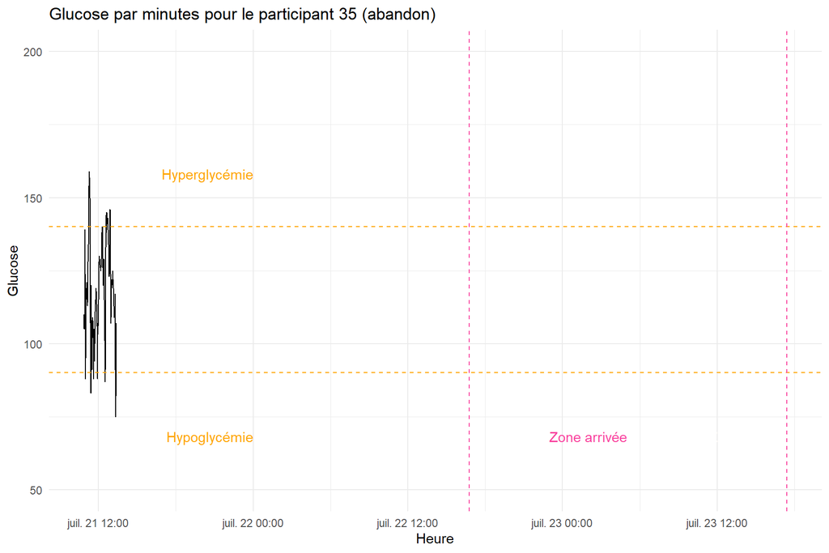

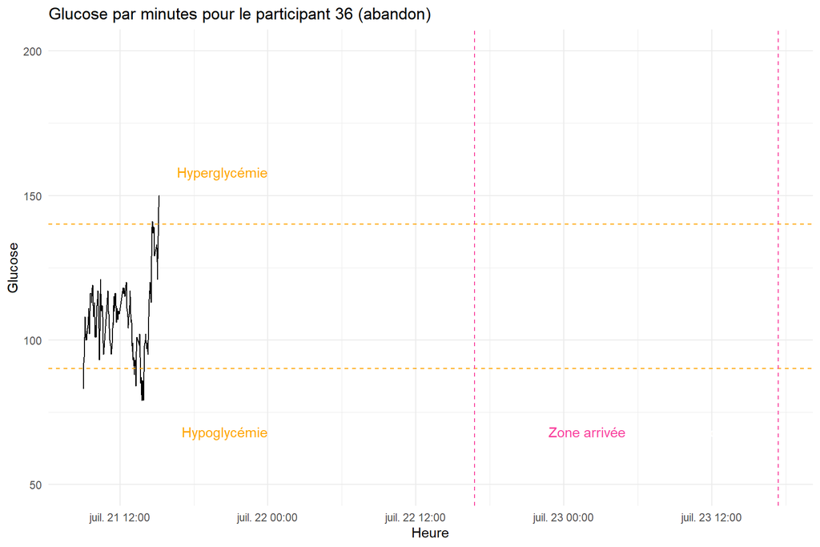

#Finisher #Coureur 1

#Coureur 5

#Coureur 7

#Coureur 8

#Coureur 9

#Coureur 17

#Coureur 20

#Coureur 22

#Coureur 24

#Coureur 25

#Coureur 28

#Coureur 30

#Coureur 33

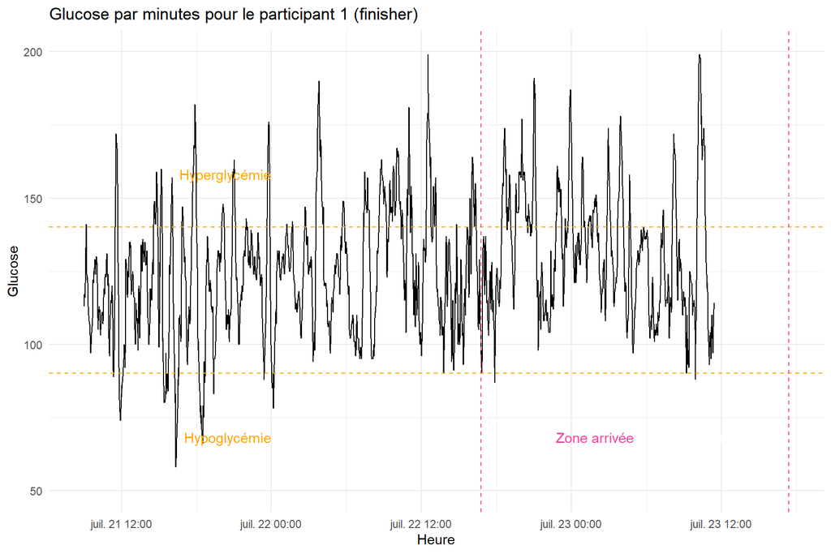

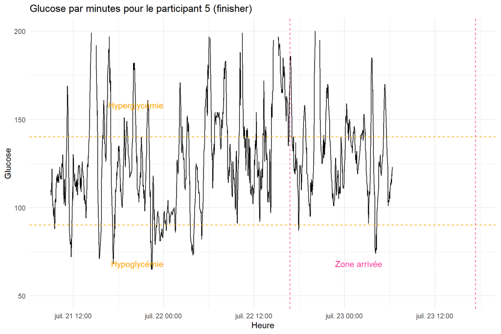

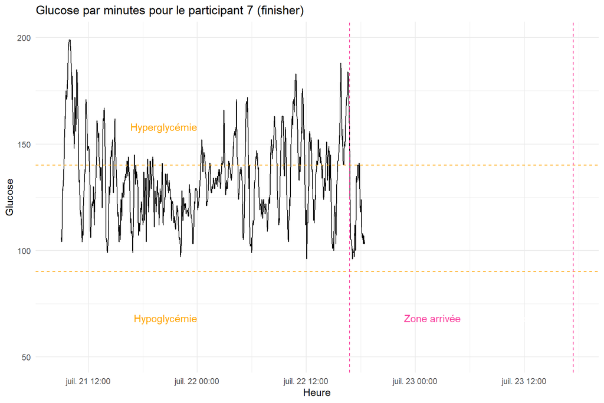

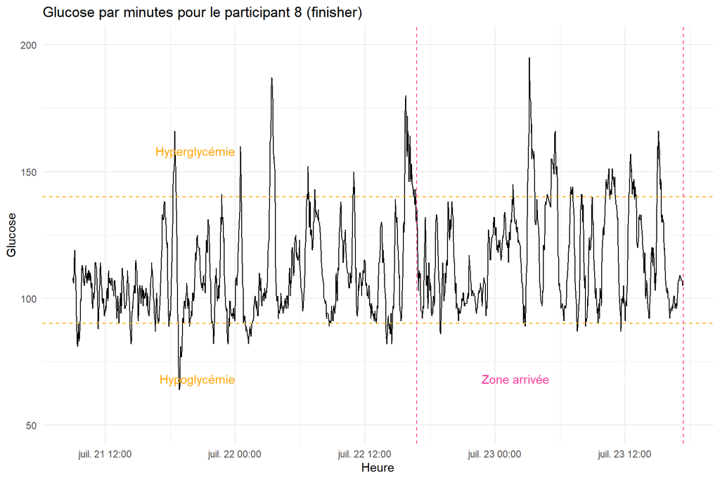

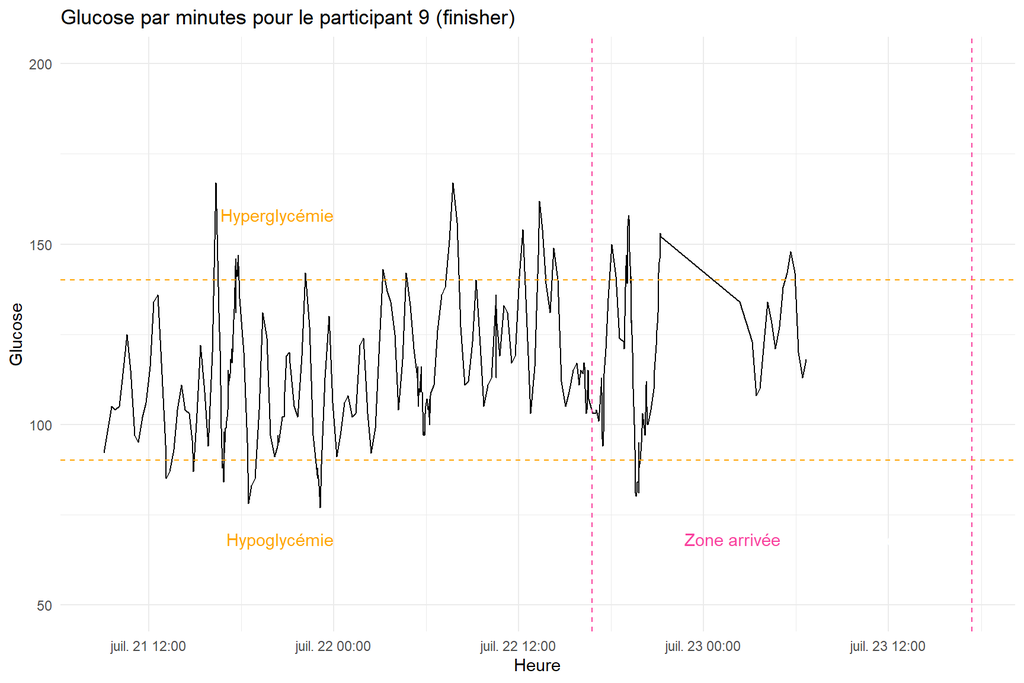

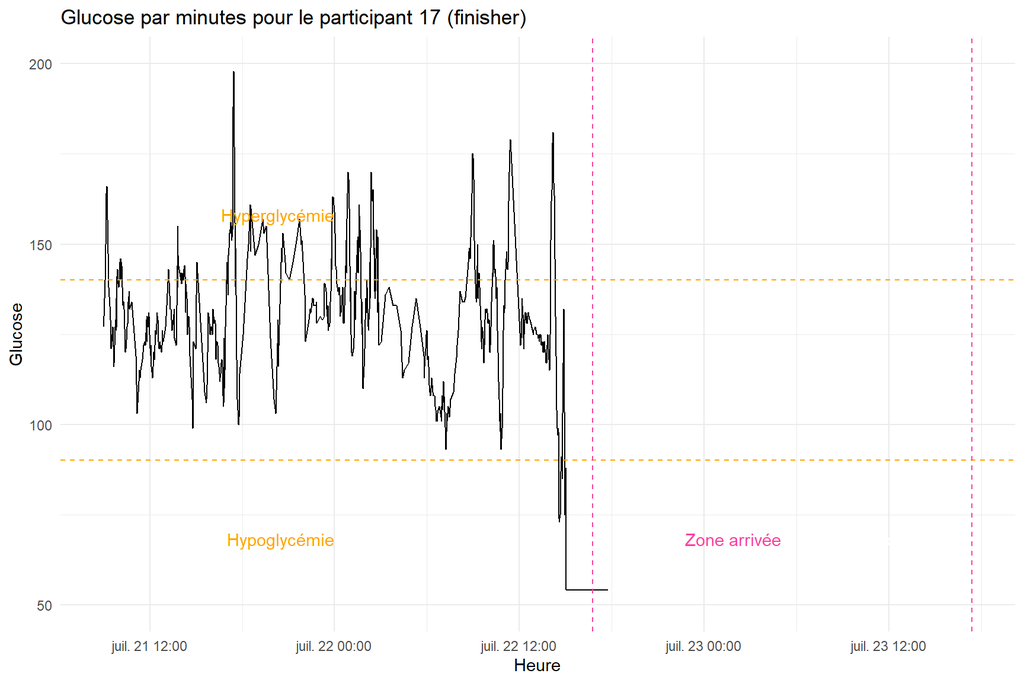

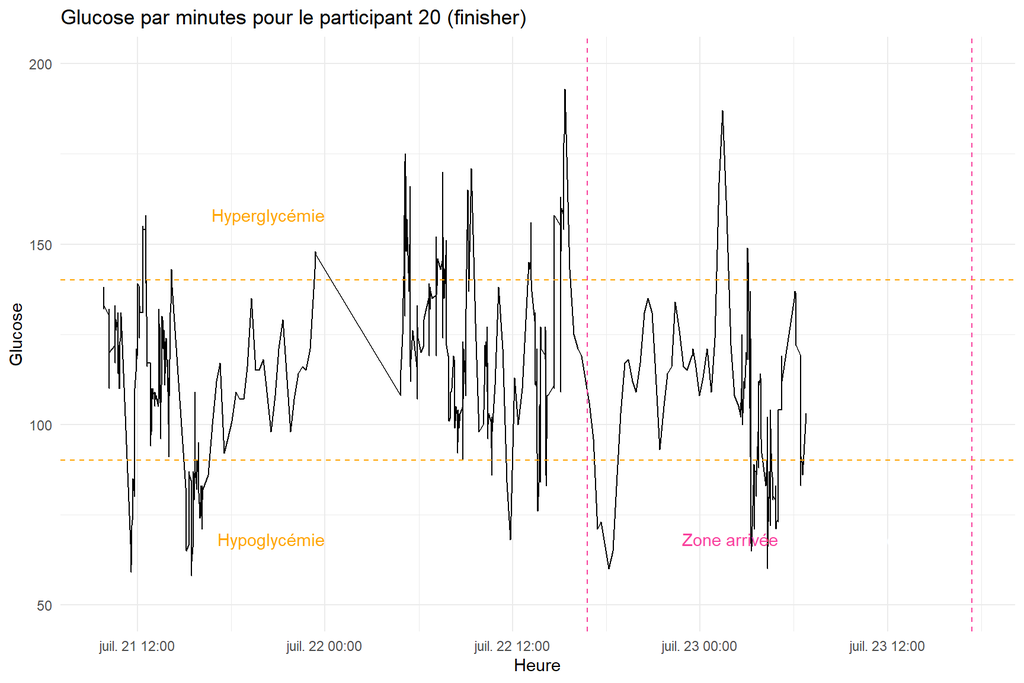

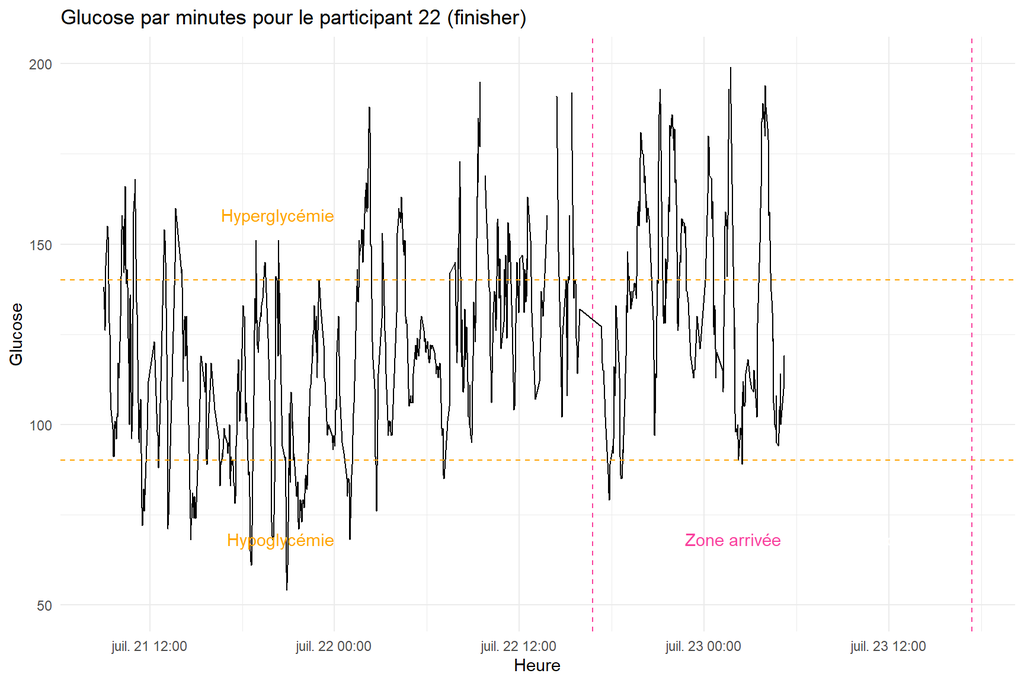

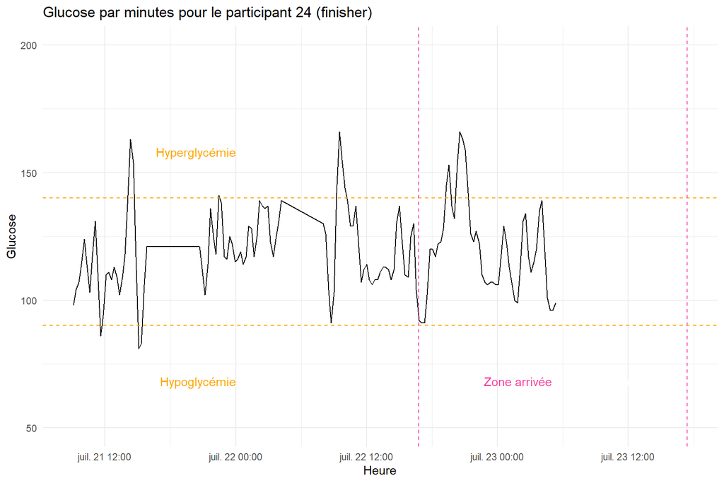

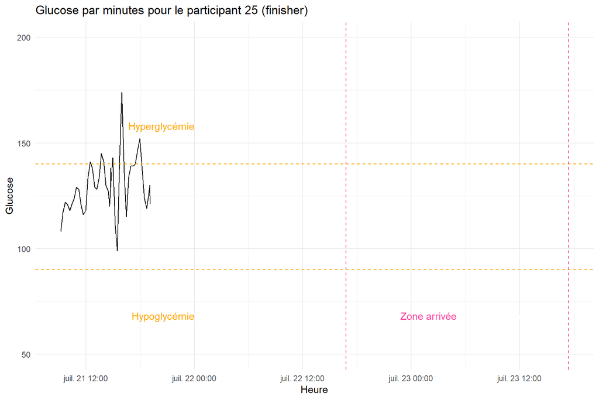

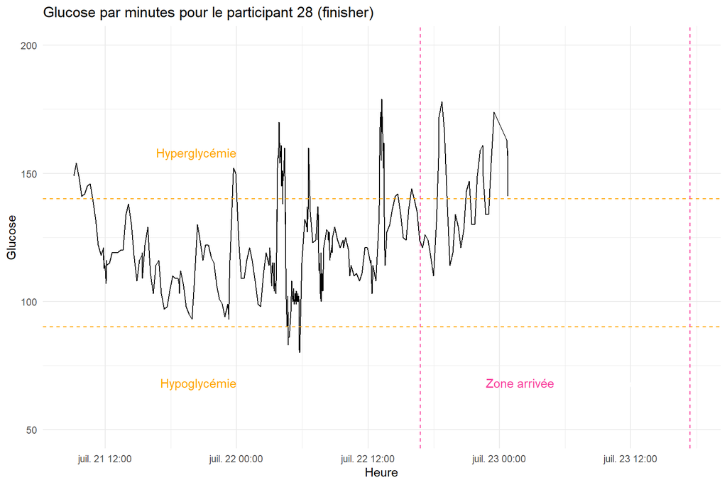

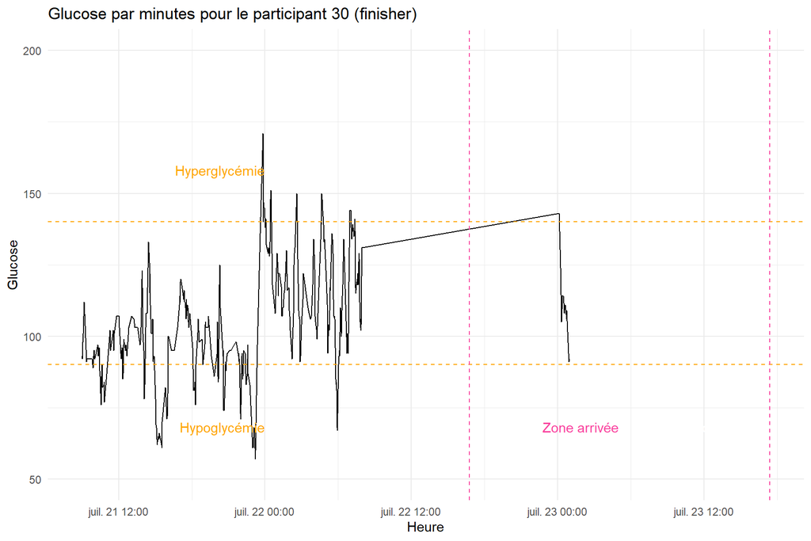

[1 more figures not shown]

#Graphique par km #Importation des données

#Mediane

#Trouver le participant median

#Creation dataframe participant median

#Quantile 0.25

#Quantile 0.75

#mise en forme des données

#Création dataframe final pour tracer le graphique avec les données médianes générales, données q1, données q3 et données du participant médian

#Graphique

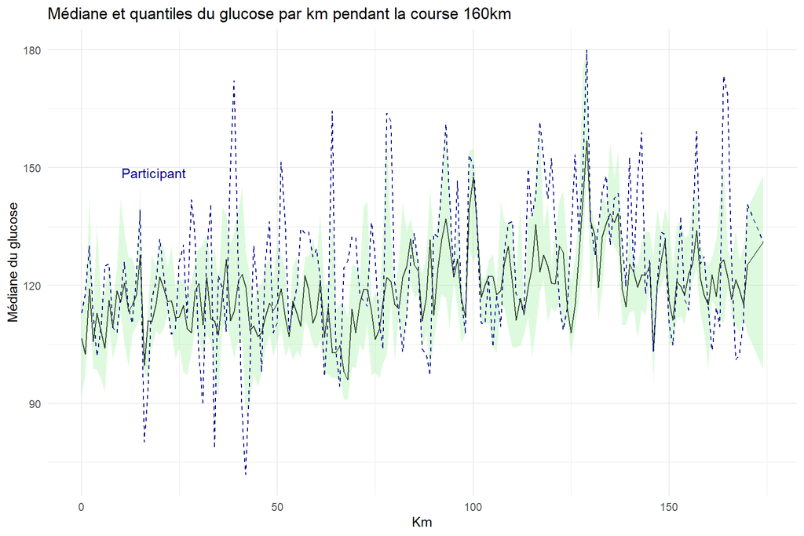